# Statystyka I z R Warsztat 13. Prosta próba losowa i rozkład statystyki z próby

Tomasz Żółtak

16 stycznia 2017

Na dzisiejszych zajęciach….

# Prosta próba losowa

### Próba a populacja

Populacja jest grupą jednostek, czy obiektów, o własnościach której chcemy wypowiedzieć się prowadząc dane badanie empiryczne. Czasem, jeśli populacja taka jest niewielka, lub interesujące nas informacje są (względnie) łatwo dostępne (np. w rejestrach państwowych, z założenia przechowujących dane o wszystkich obywatelach państwa), możemy przeanalizować informacje dotyczące wszystkich członków (elementów) populacji. Zwykle w ramach badania mamy jednak możliwość dotrzeć i zmierzyć interesujące nas własności tylko pewnej, często niezbyt licznej, podgrupy spośród członków interesującej nas populacji. Taką podgrupę będziemy nazywać **próbą**.

Na dzisiejszych zajęciach będziemy zajmować się tym, w jaki sposób można na podstawie własności jednostek wylosowanych (w określony sposób) do próby starać się wnioskować o własnościach całej populacji. Aby to sobie ułatwić przyjmiemy założenie, że znamy wartości interesującej nas cechy dla wszystkich jednostek z populacji. Umożliwi nam to porównanie, jak to, co wiemy, że ma miejsce w populacji znajduje odbicie w tym, co możemy zobaczyć, gdy będziemy losować próby. Poznamy w ten sposób własności narzędzi statystycznych służących do opisywania własności populacji na podstawie próby.

### Próba losowa

Próby mogą być dobierane w różny sposób, niekoniecznie losowy, gdyż - jak zobaczymy za chwilę - może to być w praktyce bardzo trudne, lub wręcz niewykonalne. Wykorzystanie prób losowych ma jednak pewną istotną zaletę - tylko w odniesieniu do prób losowych możemy *z czystym sumieniem* stosować techniki wnioskowania statystycznego, czyli w systematyczny i podparty teorią sposób udzielać odpowiedzi na pytanie, czy obserwowane w danych różnice - pomiędzy grupami, w stosunku do wyników wcześniejszych badań, w porównaniu do wartości, których spodziewalibyśmy się na podstawie teorii - można uznać za wynikające z tego, że podobne różnice zachodzą również w populacji, czy też wynikają one najprawdopodobniej ze specyfiki danej konkretnej próby, którą tym razem wylosowaliśmy (tego, że cechy jednostek w pojedynczej próbie różnią się zawsze w pewnym stopniu od cech całej populacji, z której próba została dobrana).

Nie wchodząc, z braku czasu, w większe szczegóły formalne, jeśli mamy do czynienia z **populacją o skończonej liczebności**, to **metodę doboru z niej jednostek do próby** możemy uznać za losową wtedy, gdy: 1. dla każdej jednostki z tej populacji jesteśmy w stanie określić prawdopodobieństwo, że w wyniku zastosowania tej procedury doboru znajdzie się ona w próbie, 2. dla każdej jednostki z tej populacji to prawdopodobieństwo musi być większe od zera.

Procedury doboru mogą w praktyce wyglądać bardzo różnie. Najprostsza do wyobrażenia sobie (i pod wieloma względami komfortowa dla badacza) jest sytuacja, w której dysponujemy spisem wszystkich jednostek należących do populacji (nazywamy go wtedy operatem losowania) i możemy na jego podstawie wylosować do próby poszczególne jednostki.

### Prosta próba losowa

Dalej będziemy się zajmować własnościami tylko dwóch szczególnych procedur doboru próby na podstawie znanego operatu, tzw. schematami doboru **prostych prób losowych**. Procedura doboru takiej próby, o założonej liczbności *n* elementów, polega na powtórzeniu *n* razy losowanie pojedynczej jednostki z danej populacji (operatu). Możemy przy tym zastosować jedno z dwóch podejść:

1. tzw. **dobór niezależny**: po wylosowaniu kolejnego elementu próby każdorazowo *zwracać* go z powrotem do populacji:
   - w ten sposób ta sama jednostka może kilkakrotnie zostać wybrana do próby - będzie w niej występować w kilku *kopiach* - może się to wydawać trochę bez sensu, ale:
     - jeśli populacja jest wielokrotnie liczniejsza od próby, prawdopodobieństwo wielokrotnego wylosowania tej same jednostki jest zaniedbywalnie małe,
     - gdybyśmy chcieli wyprowadzać wzory na rozkłady analitycznie (przy pomocy dowodów matematycznych), byłoby to w tej sytuacji dużo łatwiejsze - doświadczenie losowe losowe polegające na dobraniu pojedynczego elementu do próby jest dla każdego elementu opisywane zmienną losową o dokładnie takim samym rozkładzie (i jest to rozkład badanej zmiennej w populacji);
   - ciekawostka: możemy w ten sposób wylosować próbę bardziej liczną, niż populacja;
     - może się to wydawać pomysł cokolwiek ekscentryczny, ale też znajduje zastosowanie w pewnych dziedzinach statsytsyki (tzw. *bootstrapoewe* metody szacowania wielkości błędów standardowych);
2. tzw. **dobór zależny**:po wylosowaniu kolejnego elementu nie *zwracać* go do populacji, lecz kolejne losowania prowadzić na populacji pomniejszonej o te jednostki, które już zostały dobrane do próby:
   - jest to skądinąd sensowne, ale utrudnia rachunki (gdy wyprowadzać wzory analitycznie);
   - różnice w stosunku do doboru niezależnego uwidaczniają się tylko w sytuacji, gdy liczebność próby stanowi wystarczająco duży odestek populacji (umownie możemy przyjąć, że gdy losujemy powyżej 3%-4% populacji);
   - maksymalna możliwa liczebność próby zależnej jest oczywiście równa liczebności populacji.

### Funcja sample()

W R do losowania prostych (i nie tylko, ale nas będą interesować tylko proste) prób losowych ze skończonych populacji może nam posłużyć funkcja `sample()`.

Jeśli wektor `x` zawiera wartości interesującej nas zmiennej dla wszystkich jednostek w populacji, to możemy wylosować pojedynczą prostą, zależną próbę losową o liczebności zadanej wartością `n` wywołując `sample(x, n)`, np.:

```r
> # Niech nasza populacja składa się ze 10 osób
> #   a w zmiennej `x` będzie zapisany ich wzrost:
> x = c(178, 182, 172, 179, 183, 190, 161, 180, 176, 189)
> # wylosujmy dwuelementową próbę prostą, w sposób zależny
> sample(x, 2)
[1] 176 178
> # możemy też wylosować próbę w sposób niezależny:
> sample(x, 2, replace = TRUE)
[1] 176 161
```

Porównajmy jeszcze wyniki losowania w sposób zależny i niezależny, gdy liczebność próby jest równa liczebności populacji:

```r
> # losowanie
> probaZal = sample(x, 10)
> probaNzal = sample(x, 10, replace = TRUE)
> # aby wygodniej porównać skład, posortujmy elementy wg wartości zmiennej
> sort(x)
 [1] 161 172 176 178 179 180 182 183 189 190
> # skład próby zależnej dokładnie odpowiada składowi populacji
> sort(probaZal)
 [1] 161 172 176 178 179 180 182 183 189 190
> # a skład próby niezależnej już (raczej) nie
> sort(probaNzal)
 [1] 161 172 178 179 180 182 183 189 190 190
```

# Statystka z próby

Na podstawie próby staramy się zwykle **wnioskować na temat wartości pewnych parametrów opisujących rozkłady zmiennych w interesującej nas populacji**. W tym celu wykorzystujemy **statystyki z próby** - są to parametry rozkładu zmiennej w próbie.

- Często statystykę z próby obliczamy w sposób zupełnie analogiczny do parametru populacyjnego, o którym chcemy wnioskować (tyle że na podstawie próby).
  - Np. średnia.
- Czasem jednak wiemy, że wartości populacyjne interesującego nas parametru jest lepiej przybliżana przez statystykę z próby, którą trzeba obliczyć nieco inaczej, niż parametr w populacji.
  - Np. wariancja - używamy statystki z próby, określanej jako *odciążona wariancja*, w której sumę kwadratów odchyleń od średniej dzielimy przez liczebność próby pomniejszoną o jeden (analogiem obliczania wariancji w populacji byłoby dzielenie po prostu przez liczebność próby).

To, czy pewna statystyka z (dobranej w określony sposób) próby (o danej liczebności) stanowi *dobre* narzędzie do wnioskowania o wartościach interesującego nas parametru populacyjnego możemy oceniać badając **rozkład wartości tej statystyki w populacji wszystkich możliwych do dobrania (w określony sposób) prób**.

Jak można się dowiedzieć, jak taki rozkład wygląda?

- Tradycyjnie były one wywodzone analitycznie (twierdzenia, twierdzenia graniczne).
- Dla bardzo małych prób z małych populacji możemy rozpisać wszystkie możliwe próby i przypisać im prawdopodobieństwa.
  - W przypadku doboru prostego każda z możliwych prób jest równie prawdopodobna.
- Możemy też **przybliżyć** sobie ten rozkład wielokrotnie powtarzając daną procedurę losowania z tej samej populacji i notując wartości statystyki uzyskane za każdym razem. Oczywiście czym więcej zastosujemy powtórzeń, tym lepsze będzie nasze przybliżenie.

## Populacja wszystkich prób

Wróćmy do naszej 10-cio elementowej populacji, z której losowaliśmy dwuelementowe próby. Jak łatwo sprawdzić, różnych takich dwuelementowych prób (rozróżniając próby między sobą również ze względu na kolejność wylosowania jednostek do próby) możemy z tej populacji wylosować:

- 100 jeśli będziemy stosować dobór niezależny,
- 90 jeśli będziemy stosować dobór zależny.

W R możemy je uzyskać w następujący sposób:

```r
> # najpierw opiszemy jednostki w populacji poprzez ich numery
> #   (a nie wartości wzrostu)
> probyNzal = expand.grid(el.1 = 1:10, el.2 = 1:10)
> probyNzal = as.data.frame(probyNzal)
> probyNzal
    el.1 el.2
1      1    1
2      2    1
3      3    1
4      4    1
5      5    1
6      6    1
7      7    1
8      8    1
9      9    1
10    10    1
11     1    2
12     2    2
13     3    2
14     4    2
15     5    2
16     6    2
17     7    2
18     8    2
19     9    2
20    10    2
21     1    3
22     2    3
23     3    3
24     4    3
25     5    3
26     6    3
27     7    3
28     8    3
29     9    3
30    10    3
31     1    4
32     2    4
33     3    4
34     4    4
35     5    4
36     6    4
37     7    4
38     8    4
39     9    4
40    10    4
41     1    5
42     2    5
43     3    5
44     4    5
45     5    5
46     6    5
47     7    5
48     8    5
49     9    5
50    10    5
51     1    6
52     2    6
53     3    6
54     4    6
55     5    6
56     6    6
57     7    6
58     8    6
59     9    6
60    10    6
61     1    7
62     2    7
63     3    7
64     4    7
65     5    7
66     6    7
67     7    7
68     8    7
69     9    7
70    10    7
71     1    8
72     2    8
73     3    8
74     4    8
75     5    8
76     6    8
77     7    8
78     8    8
79     9    8
80    10    8
81     1    9
82     2    9
83     3    9
84     4    9
85     5    9
86     6    9
87     7    9
88     8    9
89     9    9
90    10    9
91     1   10
92     2   10
93     3   10
94     4   10
95     5   10
96     6   10
97     7   10
98     8   10
99     9   10
100   10   10
> # żeby mieć pewność, że w linijce poniżej usuwamy tylko to,
> #   co chcemy (a nie różne osoby, które - tak się zdarzyło -
> #   są równego wzrostu)
> probyZal = probyNzal[probyNzal$el.1 != probyNzal$el.2, ]
> probyZal
   el.1 el.2
2     2    1
3     3    1
4     4    1
5     5    1
6     6    1
7     7    1
8     8    1
9     9    1
10   10    1
11    1    2
13    3    2
14    4    2
15    5    2
16    6    2
17    7    2
18    8    2
19    9    2
20   10    2
21    1    3
22    2    3
24    4    3
25    5    3
26    6    3
27    7    3
28    8    3
29    9    3
30   10    3
31    1    4
32    2    4
33    3    4
35    5    4
36    6    4
37    7    4
38    8    4
39    9    4
40   10    4
41    1    5
42    2    5
43    3    5
44    4    5
46    6    5
47    7    5
48    8    5
49    9    5
50   10    5
51    1    6
52    2    6
53    3    6
54    4    6
55    5    6
57    7    6
58    8    6
59    9    6
60   10    6
61    1    7
62    2    7
63    3    7
64    4    7
65    5    7
66    6    7
68    8    7
69    9    7
70   10    7
71    1    8
72    2    8
73    3    8
74    4    8
75    5    8
76    6    8
77    7    8
79    9    8
80   10    8
81    1    9
82    2    9
83    3    9
84    4    9
85    5    9
86    6    9
87    7    9
88    8    9
90   10    9
91    1   10
92    2   10
93    3   10
94    4   10
95    5   10
96    6   10
97    7   10
98    8   10
99    9   10
> # teraz przypiszmy za numery obserwacji wartości wzrostu
> probyNzal$el.1 = x[probyNzal$el.1]
> probyNzal$el.2 = x[probyNzal$el.2]
> probyNzal
    el.1 el.2
1    178  178
2    182  178
3    172  178
4    179  178
5    183  178
6    190  178
7    161  178
8    180  178
9    176  178
10   189  178
11   178  182
12   182  182
13   172  182
14   179  182
15   183  182
16   190  182
17   161  182
18   180  182
19   176  182
20   189  182
21   178  172
22   182  172
23   172  172
24   179  172
25   183  172
26   190  172
27   161  172
28   180  172
29   176  172
30   189  172
31   178  179
32   182  179
33   172  179
34   179  179
35   183  179
36   190  179
37   161  179
38   180  179
39   176  179
40   189  179
41   178  183
42   182  183
43   172  183
44   179  183
45   183  183
46   190  183
47   161  183
48   180  183
49   176  183
50   189  183
51   178  190
52   182  190
53   172  190
54   179  190
55   183  190
56   190  190
57   161  190
58   180  190
59   176  190
60   189  190
61   178  161
62   182  161
63   172  161
64   179  161
65   183  161
66   190  161
67   161  161
68   180  161
69   176  161
70   189  161
71   178  180
72   182  180
73   172  180
74   179  180
75   183  180
76   190  180
77   161  180
78   180  180
79   176  180
80   189  180
81   178  176
82   182  176
83   172  176
84   179  176
85   183  176
86   190  176
87   161  176
88   180  176
89   176  176
90   189  176
91   178  189
92   182  189
93   172  189
94   179  189
95   183  189
96   190  189
97   161  189
98   180  189
99   176  189
100  189  189
> probyZal$el.1 = x[probyZal$el.1]
> probyZal$el.2 = x[probyZal$el.2]
> probyZal
   el.1 el.2
2   182  178
3   172  178
4   179  178
5   183  178
6   190  178
7   161  178
8   180  178
9   176  178
10  189  178
11  178  182
13  172  182
14  179  182
15  183  182
16  190  182
17  161  182
18  180  182
19  176  182
20  189  182
21  178  172
22  182  172
24  179  172
25  183  172
26  190  172
27  161  172
28  180  172
29  176  172
30  189  172
31  178  179
32  182  179
33  172  179
35  183  179
36  190  179
37  161  179
38  180  179
39  176  179
40  189  179
41  178  183
42  182  183
43  172  183
44  179  183
46  190  183
47  161  183
48  180  183
49  176  183
50  189  183
51  178  190
52  182  190
53  172  190
54  179  190
55  183  190
57  161  190
58  180  190
59  176  190
60  189  190
61  178  161
62  182  161
63  172  161
64  179  161
65  183  161
66  190  161
68  180  161
69  176  161
70  189  161
71  178  180
72  182  180
73  172  180
74  179  180
75  183  180
76  190  180
77  161  180
79  176  180
80  189  180
81  178  176
82  182  176
83  172  176
84  179  176
85  183  176
86  190  176
87  161  176
88  180  176
90  189  176
91  178  189
92  182  189
93  172  189
94  179  189
95  183  189
96  190  189
97  161  189
98  180  189
99  176  189
```

### Obliczanie wartości statystyk w próbach

Kiedy znamy już wartości zmiennych dla każdej obserwacji w każdej próbie, możemy po łatwo obliczyć wartości statystyki z próby dla każdej z prób. Zróbmy to dla następujących statystyk:

1. Średniej.
2. Wariancji (policzonej wzorem jak dla populacji).
3. Odciążonej wariancji (*nieobciążony estymator wariancji na podstawie prostej próby losowej*, czyli dzieląc przez *n-1* zamiast przez *n*).

```r
> probyNzal$srednia = rowMeans(probyNzal[, 1:2])
> probyNzal$wariancja = rowMeans(probyNzal[, 1:2]^2) - rowMeans(probyNzal[, 1:2])^2
> probyNzal$odc.wariancja = apply(probyNzal[, 1:2], 1, var)
> probyNzal
    el.1 el.2 srednia wariancja odc.wariancja
1    178  178   178.0      0.00           0.0
2    182  178   180.0      4.00           8.0
3    172  178   175.0      9.00          18.0
4    179  178   178.5      0.25           0.5
5    183  178   180.5      6.25          12.5
6    190  178   184.0     36.00          72.0
7    161  178   169.5     72.25         144.5
8    180  178   179.0      1.00           2.0
9    176  178   177.0      1.00           2.0
10   189  178   183.5     30.25          60.5
11   178  182   180.0      4.00           8.0
12   182  182   182.0      0.00           0.0
13   172  182   177.0     25.00          50.0
14   179  182   180.5      2.25           4.5
15   183  182   182.5      0.25           0.5
16   190  182   186.0     16.00          32.0
17   161  182   171.5    110.25         220.5
18   180  182   181.0      1.00           2.0
19   176  182   179.0      9.00          18.0
20   189  182   185.5     12.25          24.5
21   178  172   175.0      9.00          18.0
22   182  172   177.0     25.00          50.0
23   172  172   172.0      0.00           0.0
24   179  172   175.5     12.25          24.5
25   183  172   177.5     30.25          60.5
26   190  172   181.0     81.00         162.0
27   161  172   166.5     30.25          60.5
28   180  172   176.0     16.00          32.0
29   176  172   174.0      4.00           8.0
30   189  172   180.5     72.25         144.5
31   178  179   178.5      0.25           0.5
32   182  179   180.5      2.25           4.5
33   172  179   175.5     12.25          24.5
34   179  179   179.0      0.00           0.0
35   183  179   181.0      4.00           8.0
36   190  179   184.5     30.25          60.5
37   161  179   170.0     81.00         162.0
38   180  179   179.5      0.25           0.5
39   176  179   177.5      2.25           4.5
40   189  179   184.0     25.00          50.0
41   178  183   180.5      6.25          12.5
42   182  183   182.5      0.25           0.5
43   172  183   177.5     30.25          60.5
44   179  183   181.0      4.00           8.0
45   183  183   183.0      0.00           0.0
46   190  183   186.5     12.25          24.5
47   161  183   172.0    121.00         242.0
48   180  183   181.5      2.25           4.5
49   176  183   179.5     12.25          24.5
50   189  183   186.0      9.00          18.0
51   178  190   184.0     36.00          72.0
52   182  190   186.0     16.00          32.0
53   172  190   181.0     81.00         162.0
54   179  190   184.5     30.25          60.5
55   183  190   186.5     12.25          24.5
56   190  190   190.0      0.00           0.0
57   161  190   175.5    210.25         420.5
58   180  190   185.0     25.00          50.0
59   176  190   183.0     49.00          98.0
60   189  190   189.5      0.25           0.5
61   178  161   169.5     72.25         144.5
62   182  161   171.5    110.25         220.5
63   172  161   166.5     30.25          60.5
64   179  161   170.0     81.00         162.0
65   183  161   172.0    121.00         242.0
66   190  161   175.5    210.25         420.5
67   161  161   161.0      0.00           0.0
68   180  161   170.5     90.25         180.5
69   176  161   168.5     56.25         112.5
70   189  161   175.0    196.00         392.0
71   178  180   179.0      1.00           2.0
72   182  180   181.0      1.00           2.0
73   172  180   176.0     16.00          32.0
74   179  180   179.5      0.25           0.5
75   183  180   181.5      2.25           4.5
76   190  180   185.0     25.00          50.0
77   161  180   170.5     90.25         180.5
78   180  180   180.0      0.00           0.0
79   176  180   178.0      4.00           8.0
80   189  180   184.5     20.25          40.5
81   178  176   177.0      1.00           2.0
82   182  176   179.0      9.00          18.0
83   172  176   174.0      4.00           8.0
84   179  176   177.5      2.25           4.5
85   183  176   179.5     12.25          24.5
86   190  176   183.0     49.00          98.0
87   161  176   168.5     56.25         112.5
88   180  176   178.0      4.00           8.0
89   176  176   176.0      0.00           0.0
90   189  176   182.5     42.25          84.5
91   178  189   183.5     30.25          60.5
92   182  189   185.5     12.25          24.5
93   172  189   180.5     72.25         144.5
94   179  189   184.0     25.00          50.0
95   183  189   186.0      9.00          18.0
96   190  189   189.5      0.25           0.5
97   161  189   175.0    196.00         392.0
98   180  189   184.5     20.25          40.5
99   176  189   182.5     42.25          84.5
100  189  189   189.0      0.00           0.0
> probyZal$srednia = rowMeans(probyZal[, 1:2])
> probyZal$wariancja = rowMeans(probyZal[, 1:2]^2) - rowMeans(probyZal[, 1:2])^2
> probyZal$odc.wariancja = apply(probyZal[, 1:2], 1, var)
> probyZal
   el.1 el.2 srednia wariancja odc.wariancja
2   182  178   180.0      4.00           8.0
3   172  178   175.0      9.00          18.0
4   179  178   178.5      0.25           0.5
5   183  178   180.5      6.25          12.5
6   190  178   184.0     36.00          72.0
7   161  178   169.5     72.25         144.5
8   180  178   179.0      1.00           2.0
9   176  178   177.0      1.00           2.0
10  189  178   183.5     30.25          60.5
11  178  182   180.0      4.00           8.0
13  172  182   177.0     25.00          50.0
14  179  182   180.5      2.25           4.5
15  183  182   182.5      0.25           0.5
16  190  182   186.0     16.00          32.0
17  161  182   171.5    110.25         220.5
18  180  182   181.0      1.00           2.0
19  176  182   179.0      9.00          18.0
20  189  182   185.5     12.25          24.5
21  178  172   175.0      9.00          18.0
22  182  172   177.0     25.00          50.0
24  179  172   175.5     12.25          24.5
25  183  172   177.5     30.25          60.5
26  190  172   181.0     81.00         162.0
27  161  172   166.5     30.25          60.5
28  180  172   176.0     16.00          32.0
29  176  172   174.0      4.00           8.0
30  189  172   180.5     72.25         144.5
31  178  179   178.5      0.25           0.5
32  182  179   180.5      2.25           4.5
33  172  179   175.5     12.25          24.5
35  183  179   181.0      4.00           8.0
36  190  179   184.5     30.25          60.5
37  161  179   170.0     81.00         162.0
38  180  179   179.5      0.25           0.5
39  176  179   177.5      2.25           4.5
40  189  179   184.0     25.00          50.0
41  178  183   180.5      6.25          12.5
42  182  183   182.5      0.25           0.5
43  172  183   177.5     30.25          60.5
44  179  183   181.0      4.00           8.0
46  190  183   186.5     12.25          24.5
47  161  183   172.0    121.00         242.0
48  180  183   181.5      2.25           4.5
49  176  183   179.5     12.25          24.5
50  189  183   186.0      9.00          18.0
51  178  190   184.0     36.00          72.0
52  182  190   186.0     16.00          32.0
53  172  190   181.0     81.00         162.0
54  179  190   184.5     30.25          60.5
55  183  190   186.5     12.25          24.5
57  161  190   175.5    210.25         420.5
58  180  190   185.0     25.00          50.0
59  176  190   183.0     49.00          98.0
60  189  190   189.5      0.25           0.5
61  178  161   169.5     72.25         144.5
62  182  161   171.5    110.25         220.5
63  172  161   166.5     30.25          60.5
64  179  161   170.0     81.00         162.0
65  183  161   172.0    121.00         242.0
66  190  161   175.5    210.25         420.5
68  180  161   170.5     90.25         180.5
69  176  161   168.5     56.25         112.5
70  189  161   175.0    196.00         392.0
71  178  180   179.0      1.00           2.0
72  182  180   181.0      1.00           2.0
73  172  180   176.0     16.00          32.0
74  179  180   179.5      0.25           0.5
75  183  180   181.5      2.25           4.5
76  190  180   185.0     25.00          50.0
77  161  180   170.5     90.25         180.5
79  176  180   178.0      4.00           8.0
80  189  180   184.5     20.25          40.5
81  178  176   177.0      1.00           2.0
82  182  176   179.0      9.00          18.0
83  172  176   174.0      4.00           8.0
84  179  176   177.5      2.25           4.5
85  183  176   179.5     12.25          24.5
86  190  176   183.0     49.00          98.0
87  161  176   168.5     56.25         112.5
88  180  176   178.0      4.00           8.0
90  189  176   182.5     42.25          84.5
91  178  189   183.5     30.25          60.5
92  182  189   185.5     12.25          24.5
93  172  189   180.5     72.25         144.5
94  179  189   184.0     25.00          50.0
95  183  189   186.0      9.00          18.0
96  190  189   189.5      0.25           0.5
97  161  189   175.0    196.00         392.0
98  180  189   184.5     20.25          40.5
99  176  189   182.5     42.25          84.5
```

### Porównajmy teraz uzyskane rozkłady statystyk ze znanymi wartościami populacynymi:

#### Średni wzorst

Średni wzrost w naszej 10-cio elementowej populacji to:

```r
> mean(x)
[1] 179
```

Rozkłady statystyki *średnia z próby* mają następujące parametry (są to: średnia statystyki *średnia z próby* i wariancja statsystyki *średnia z próby*):

```r
> round(c("srednia" = mean(probyZal$srednia),
+         "wariancja" = var(probyZal$srednia)*9/10), 1)
  srednia wariancja
    179.0      25.5
> round(c("srednia" = mean(probyNzal$srednia),
+         "wariancja" = var(probyNzal$srednia)*9/10), 1)
  srednia wariancja
    179.0      28.6
```

Warto zauważyć, że:

- bez względu na sposób losowania (zależny/niezależny) średnia wartość statystyki *średnia z próby* w populacji wszystkich możliwych prób jest równa wartości parametru *średnia* w badanej (10-cio osobowej) populacji;
- rozkład statystyki *średnia z próby* ma większą wariancję przy losowaniu niezależnym, niż przy zależnym.

O statystyce, która posiada pierwszą z opisanych wyżej własności mówimy, że jest **nieobciążonym estymatorem** odpowiedniego parametru populacyjnego (przy danym schemacie doboru próby). Statystyka *średnia z (prostej losowej) próby* jest więc nieobciążonym estymatorem średniej populacyjnej.

Jeśli chodzi o drugą z opisanych własności, to wolimy oczywiście posługiwać się takim estymatorem, którego wartości skupiają się bliżej wartości populacyjnego parametru, o którym chcemy wnioskować. Jeśli estymator jest nieobciążony, to jego wariancja może być wykorzystana jako wskaźnik właśnie tej jego własności. W związku z tym możemy dojść do wniosku, że lepiej byłoby stosować dobór zależny, bo wariancja statystyki *średnia z próby* jest przy takiej metodzie doboru mniejsza, niż gdy losujemy próbę niezależnie. Możemy powiedzieć, że **losowanie zależne jest bardziej efektywne niż losowanie niezależne**.

Znając rozkład statystki z próby możemy też zadać pytanie, jakie jest prawdopodobieństwo, że wylosujemy próbę, w której wartość tej statystyki będzie się różnić od parametru populacyjnego o nie więcej niż pewna zadana wartość. Np. prawdopodobieństwo wylosowania dwuosobowej próby takiej, że statystyka *średnia z próby* będzie się różnić od średniego wzrostu w naszej 10-cio osobowej populacji o nie więcej niż 5 cm wynosi: - przy doborze prostym zależnym:

```r
> sum(abs(probyZal$srednia - mean(x)) <= 5) / nrow(probyZal)
[1] 0.6666667
```

- przy doborze prostym niezależnym:

```r
> sum(abs(probyNzal$srednia - mean(x)) <= 5) / nrow(probyNzal)
[1] 0.66
```

#### Wariancja wzrostu

W naszej 10-cio elementowej populacji wariancja wzrostu wynosi:

```r
> mean(x^2) - mean(x)^2
[1] 63
```

Rozkłady statystyki *wariancja z próby* mają następujące parametry (są to: średnia statystyki *wariancja z próby* i wariancja statsystyki *wariancja z próby*):

```r
> round(c("srednia" = mean(probyZal$wariancja),
+         "wariancja" = var(probyZal$wariancja)*89/90), 1)
  srednia wariancja
     35.0    2268.2
> round(c("srednia" = mean(probyNzal$wariancja),
+         "wariancja" = var(probyNzal$wariancja)*99/100), 1)
  srednia wariancja
     31.5    2151.6
```

Rozkłady statystyki *odciążona wariancja z próby* mają następujące parametry (są to: średnia statystyki *odciążona wariancja z próby* i wariancja statsystyki *odciążona wariancja z próby*):

```r
> round(c("srednia" = mean(probyZal$odc.wariancja),
+         "wariancja" = var(probyZal$odc.wariancja)*89/90), 1)
  srednia wariancja
     70.0    9072.7
> round(c("srednia" = mean(probyNzal$odc.wariancja),
+         "wariancja" = var(probyNzal$odc.wariancja)*99/100), 1)
  srednia wariancja
     63.0    8606.4
```

Warto zauważyć, że:

- wartości statystyki *wariancja z próby* są średnio o około połowę mniejsze, niż populacyjna wartość wariancji;
- średnia wartość statystyki *odciążona wariancja z próby* jest równa populacyjnej wartości wariancji, ale tylko jeśli dobieramy próbę w sposób prosty niezależny;
- statystyka *wariancja z próby* ma co prawda dużo mniejszą wariancję, niż statystyka *odciążona wariancja z próby*, ale w tym przypadku raczej nie świadczy to na jej korzyść - jej rozkład jestbardziej skupiony, ale blisko niepożądanej wartości (p. wyżej).

Należy jednak nadmienić, że widoczne tu dosyć spektakularne różnice pomiędzy własnościami statystyk *wariancja z próby* i *odciążona wariancja z próby* **są specyficzne dla próby o niewielkiej liczebności** i szybko zmniejszałyby się, gdyby chcieć rozpatrywać próby liczące coraz więcej elementów.

## Symulacyjne przybliżanie rozkładu statystyki w populacji wszystkich prób

W miarę wzrostu liczebności próby populacja wszystkich prób bardzo szybko staje się niemożliwa do rozpatrzenia w sposób opisany powyżej, gdyż staje się zbyt liczna. W takiej sytuacji (oprócz dowodów analitycznych) możemy ucieć się do symulacji, tj. przybliżyć sobie własności rozkładu interesującej nas statystyki w populacji wszystkich prób, analizując jej własności w wystarczająco dużej podgrupie (*de facto* też próbie, tylko dobranej z populacji wszystkich prób) spośród wszystkich możliwych prób.

Aby tego dokonać będziemy po prostu wielokrotnie (kilka-kilkaset tysięcy razy - zależy to jeszcze od parametru, który nas interesuje) powtarzać założoną procedurę losowania, a dla każdej z wylosowanych prób obliczać wartość interesującej nas statystyki, aby potem móc przeanalizować ich rozkład.

### Pętla for

Aby wielokrotnie powtórzyć tą samą procedurę posłużymy się pętlą `for()`. W R ma ona postać analogiczną jak w Pythonie (a więc analogiczną jak pętla `foreach()` w językach o składni pochodnej od C), a więc w kolejnych obiegach pętla przypisuje wyznaczonej zmiennej kolejne wartości zadanego wektora:

```r
> for (i in 1:5) {
+   print(i)
+ }
[1] 1
[1] 2
[1] 3
[1] 4
[1] 5
```

### Własności statystyki średnia z próby w dużej próbie

Załóżmy, że interesująca nas populacja liczy 1 mln osób i że dla wszystkich z nich znamy wartości wzrostu i to, czy są to osoby praworęczne, czy leworęczne. Niech wzrost w naszej populacji, opisywany zmienną `w`, ma rozkład zbliżony do normalnego o średniej 178 i odchyleniu standardowym 6:

```r
> w = rnorm(10^6, 178, 6)
```

Z kolei zmienna `r` przyjmuje wartości 1 dla leworęcznych a 0 dla praworęcznych, przy czym praworęczni stanowią 70% populacji i cecha ta jest niezwiązana ze wzrostem.

```r
> r = c(rep(0, 10^6 * 0.7), rep(1, 10^6 * 0.3))
> summary(cbind(w, r))
       w               r
 Min.   :149.0   Min.   :0.0
 1st Qu.:173.9   1st Qu.:0.0
 Median :178.0   Median :0.0
 Mean   :178.0   Mean   :0.3
 3rd Qu.:182.1   3rd Qu.:1.0
 Max.   :206.7   Max.   :1.0
```

Możemy też narysować ich rozkłady:

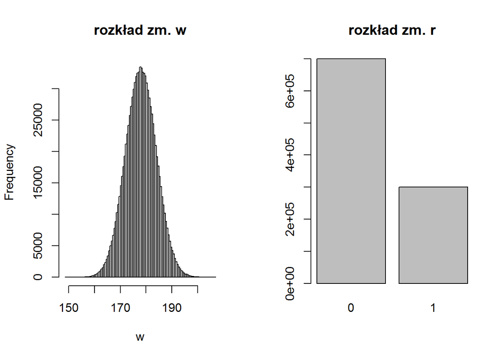

```r
> split.screen(c(1,2))
[1] 1 2
> hist(w, 100, main = "rozkład zm. w")
> screen(2)
> plot(factor(r), main = "rozkład zm. r")
```

```r
> close.screen(all = TRUE)
```

Będą interesować nas własności statystyki *średnia w próbie* przy losowaniu w sposób prosty, zależny dosyć dużych, **400 osobowych prób**.

#### Symulacja

Żeby wystarczająco dobrze przybliżyć sobie te własności, musimy powtórzyć losowanie bardzo dużą liczbę razy - przyjmijmy, że zrobimy to 10 tys. razy. Nasza symulacja będzie wyglądać w ten sposób:

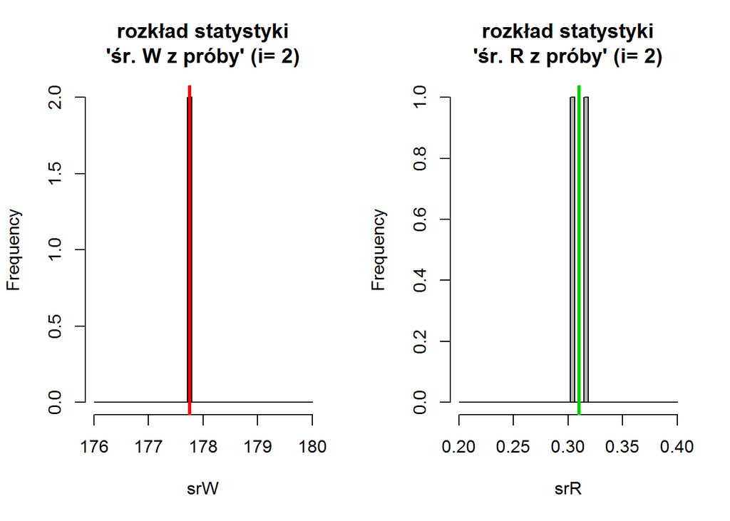

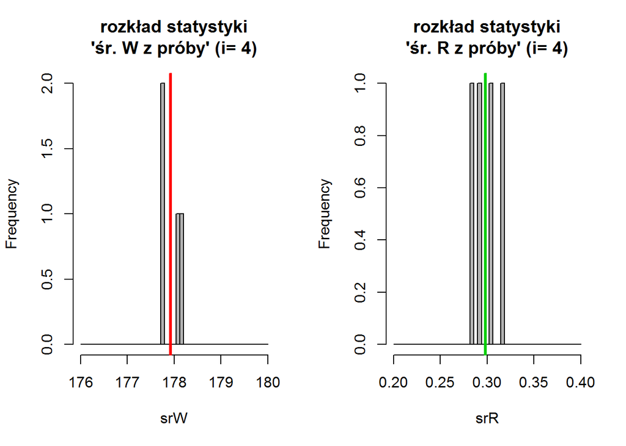

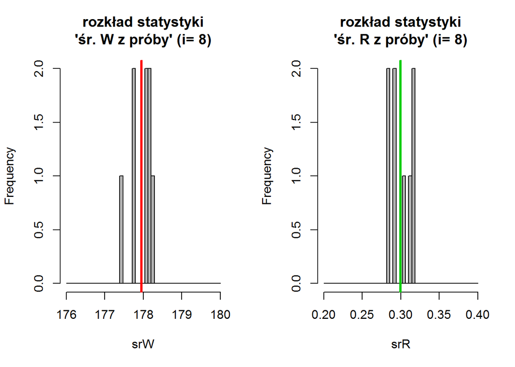

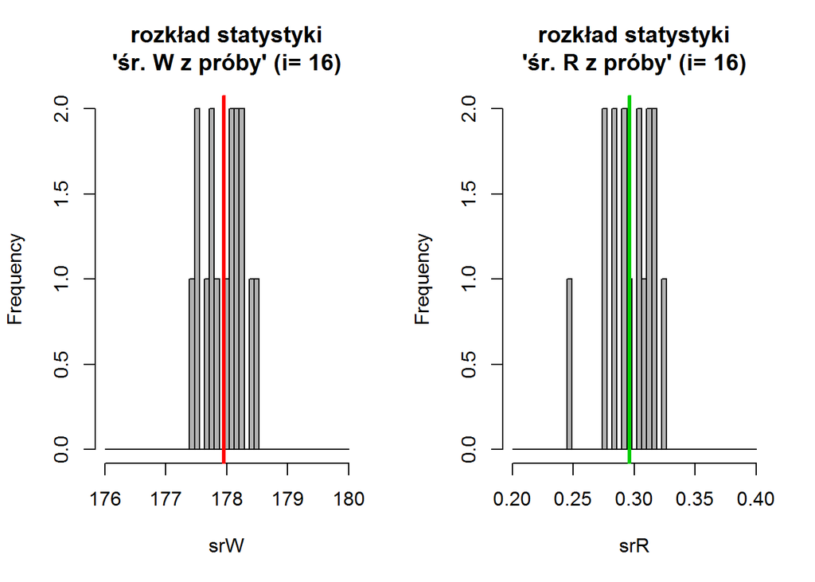

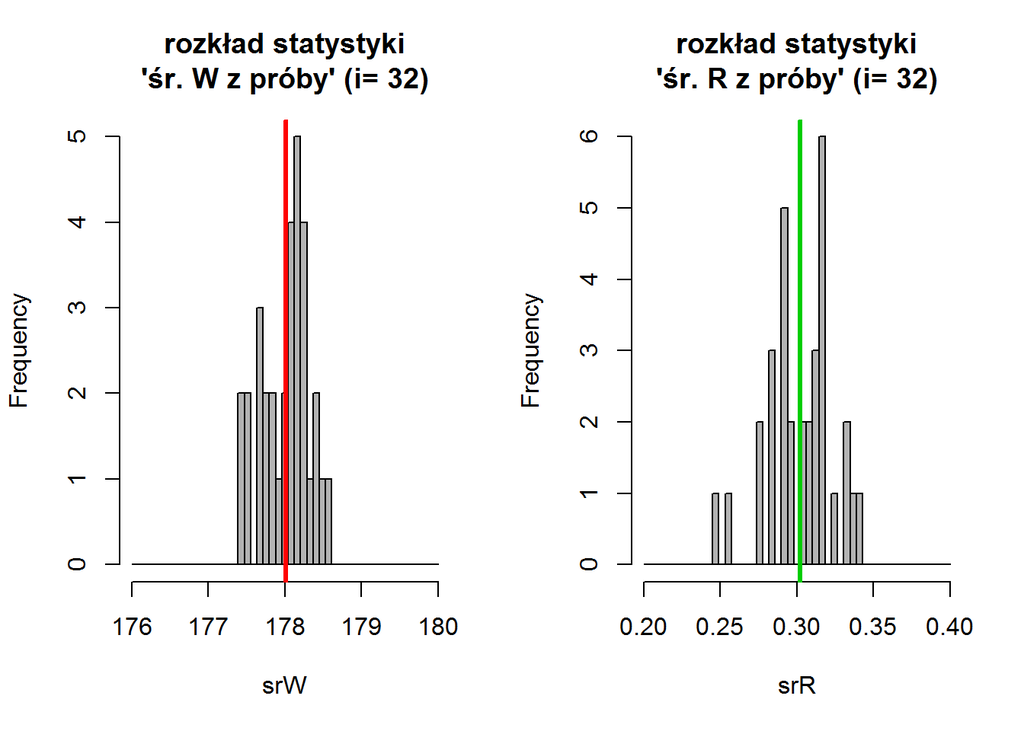

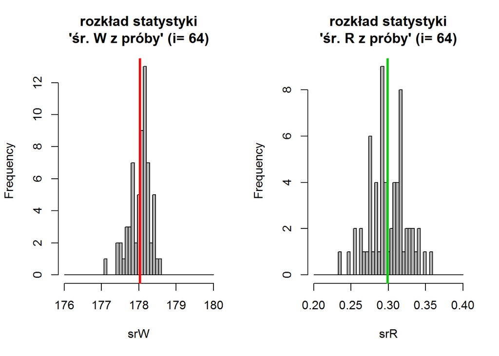

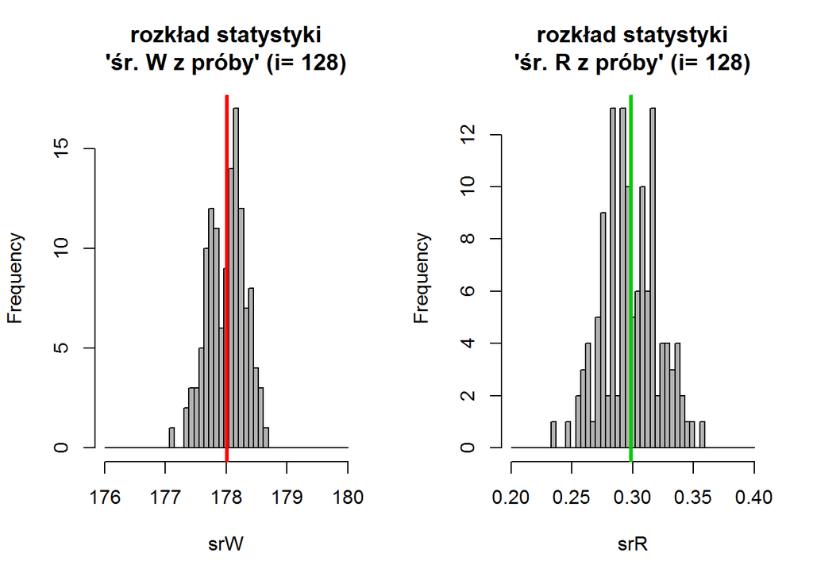

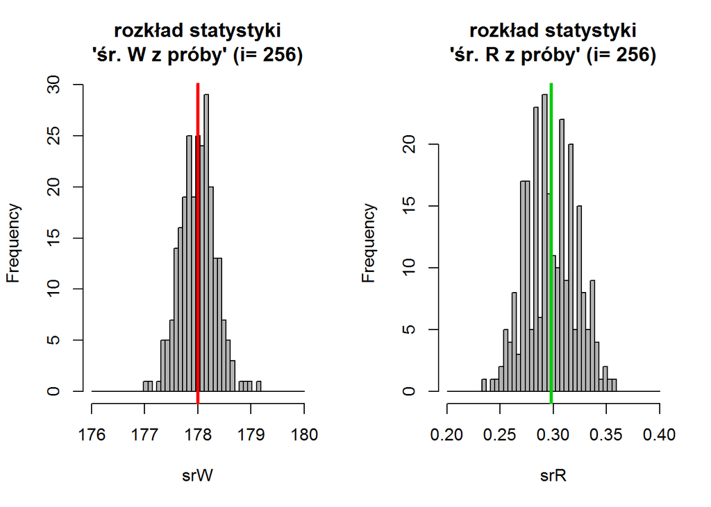

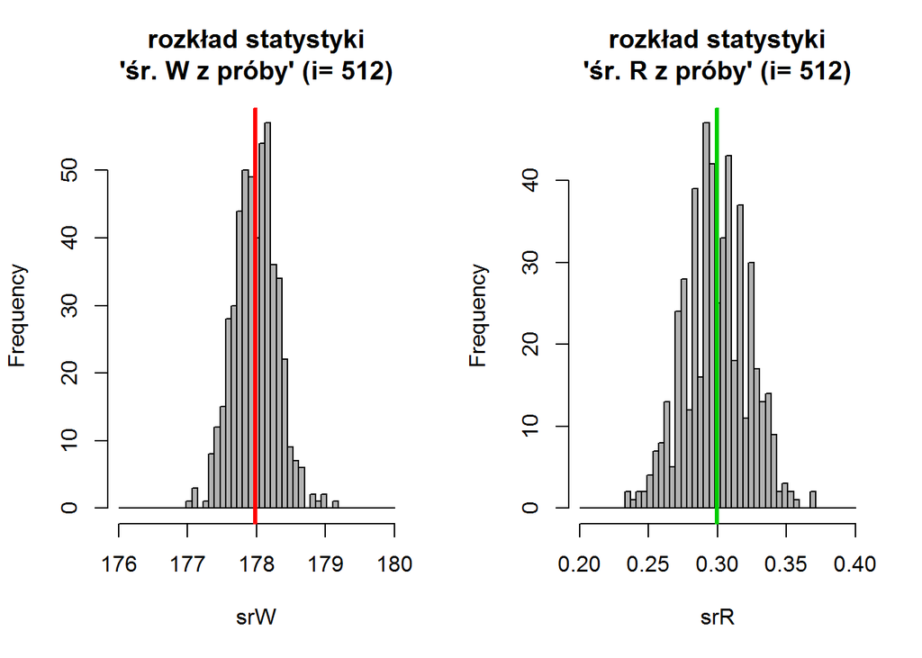

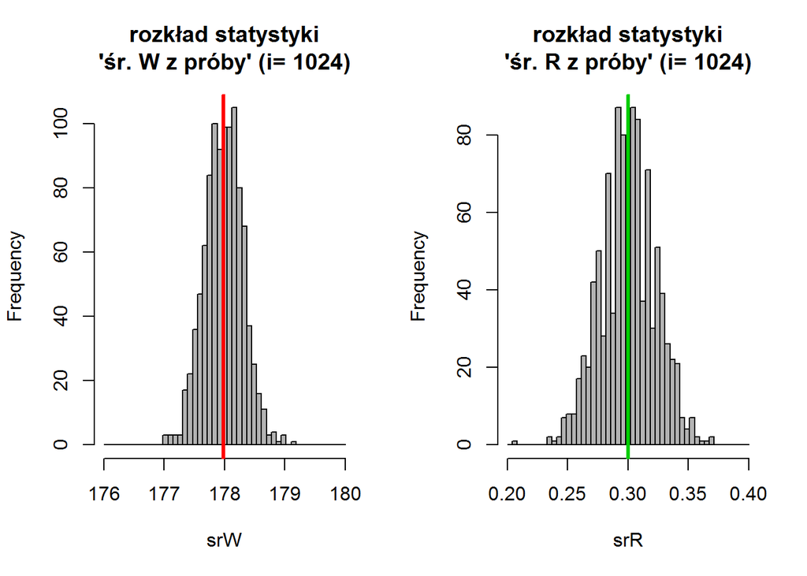

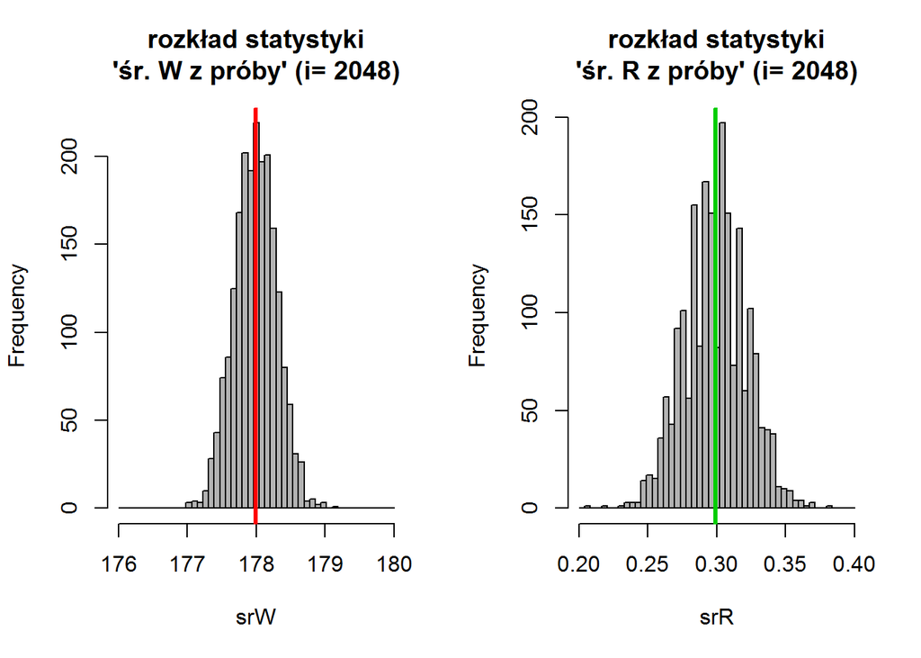

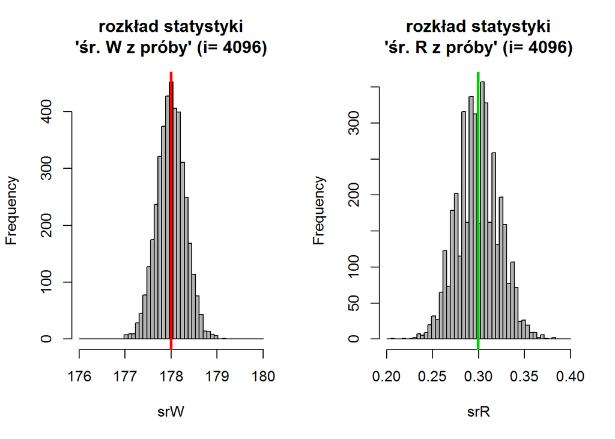

[1 more figures not shown]

```r
> # liczba powtórzeń losowania
> lPowt = 10^4
> # liczebność próby
> n = 400
> # tworzymy wektory, w których będziemy zapisywać wartości
> # statystyk "średnia z próby""
> srW = rep(NA, lPowt)
> srR = rep(NA, lPowt)
> # dwie rzeczy konieczne do wizualizacji
> layout(matrix(c(1, 2), nrow = 1))
> j = 2
> # i powtarzamy losowanie, korzystając z pętli for()
> #   to potrwa dłuższą chwilę
> for (i in 1:lPowt) {
+   # losujemy numery osób w populacji
+   proba = sample(1:length(w), n)
+   # i obliczone dla nich średnie zapisujemy w `srW` i `srR`
+   srW[i] = mean(w[proba])
+   srR[i] = mean(r[proba])
+   # wizualizacja (stramy sięnie rysować za często)
+   if (i == j) {
+     j = j * 2
+     hist(srW, seq(176, 180, length.out = 50), col = grey(0.7),
+          main = paste0("rozkład statystyki\n'śr. W z próby' (i= ", i, ")"))
+     abline(v = mean(srW, na.rm = TRUE), lwd = 3, col = 2)
+     hist(srR, seq(0.2, 0.4, length.out = 50), col = grey(0.7),
+          main = paste0("rozkład statystyki\n'śr. R z próby' (i= ", i, ")"))
+     abline(v = mean(srR, na.rm = TRUE), lwd = 3, col = 3)
+   }
+ }
```

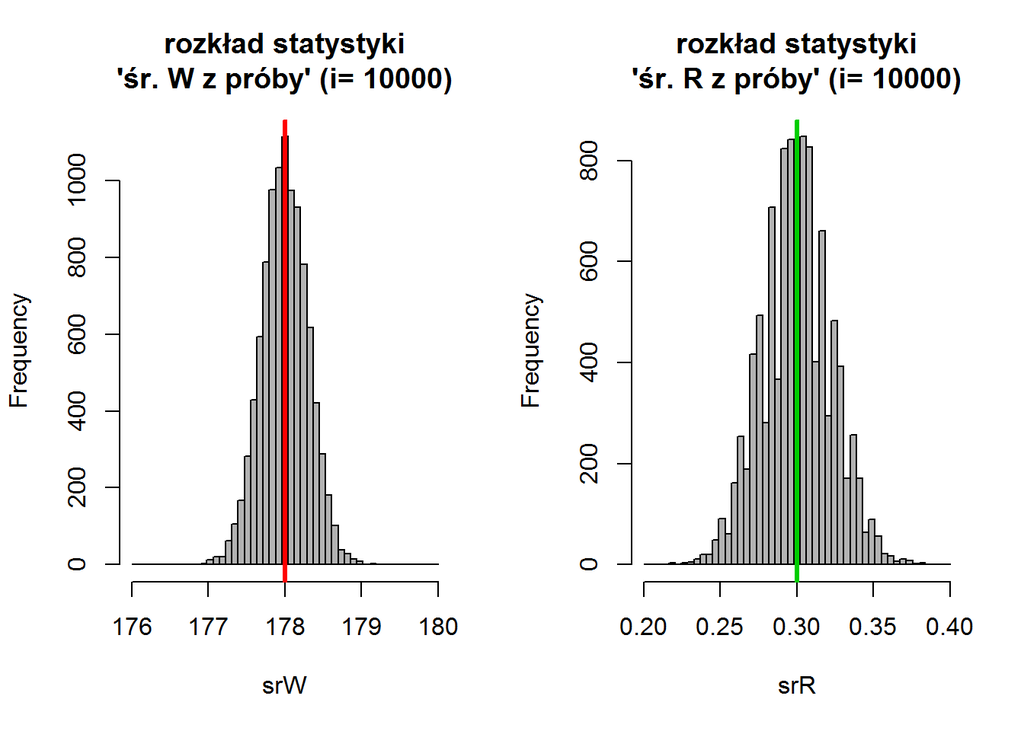

```r
> # i jeszcze końcowe rozkłady
> hist(srW, seq(176, 180, length.out = 50), col = grey(0.7),
+      main = paste0("rozkład statystyki\n'śr. W z próby' (i= ", i, ")"))
> abline(v = mean(srW, na.rm = TRUE), lwd = 3, col = 2)
> hist(srR, seq(0.2, 0.4, length.out = 50), col = grey(0.7),
+      main = paste0("rozkład statystyki\n'śr. R z próby' (i= ", i, ")"))
> abline(v = mean(srR, na.rm = TRUE), lwd = 3, col = 3)
```

```r
> layout(1)
```

#### Analiza wyników symulacji

Czego spodziewamy się po rozkładach statystyki *średnia z próby* dla zmiennej `w` i dla zmiennej `r`?

Na mocy Centralnego Twierdzenia Granicznego (CTG) powinny one zbiegać do rozkładów normalnych i to zarówno dla zmiennej `w`, jak i dla zmiennej `r` (mimo że ich rozkłady populacyjne są bardzo różne). Parametry tych rozkładów, zgodnie z CTG powinny wynosić:

- dla rozkładu statystyki *średnia zmiennej `w` z próby*:
  - wartość oczekiwana 178 (równa średniej zmiennej `w` w populacji),
  - odch. std. 0,3 (równe odch. std. zmiennej `w` w populacji, podzielonemu przez pierwiastek kwadratowy z liczebności próby: `6 / 400^0.5 = 6 / 20`).
  - w wynikach naszej symulacji wynoszą zaś:

```r
> c(srednia = mean(srW), odch.std. = sd(srW) * sqrt((lPowt - 1) / lPowt))
    srednia   odch.std.
177.9979262   0.3005888
```

- dla rozkładu statystyki *średnia zmiennej `r` z próby*:
  - wartość oczekiwana 0,3 (równa średniej zmiennej `r` w populacji),
  - odch. std. ~0,0229 (równe odch. std. zmiennej `r` w populacji, podzielonemu przez pierwiastek kwadratowy z liczebności próby: `(0.3 * 0.7)^0.5 / 400^0.5 = 0.458 / 20`).
  - w wynikach naszej symulacji wynoszą zaś:

```r
> c(srednia = mean(srR), odch.std. = sd(srR) * sqrt((lPowt - 1) / lPowt))
   srednia  odch.std.
0.29998925 0.02282779
```

Możemy też prześledzić, jak średnie interesujących nas statystyk zmieniały się wraz z kolejnymi obiegami pętli w przeprowadzonej symulacji.

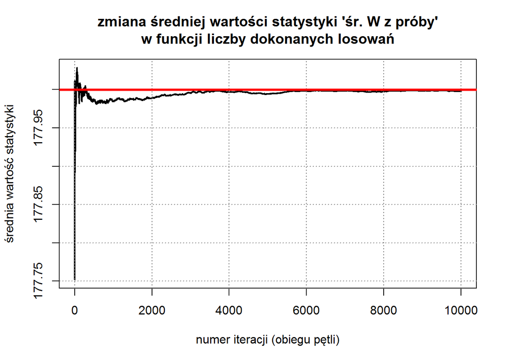

```r
> srSrW = cumsum(srW) / (1:lPowt)
> plot(1:lPowt, srSrW, type = "l", lwd = 2,
+      main = "zmiana średniej wartości statystyki 'śr. W z próby'\nw funkcji liczby dokonanych losowań",
+      xlab = "numer iteracji (obiegu pętli)", ylab = "średnia wartość statystyki")
> grid(col = grey(0.5))
> abline(h = mean(w), col = 2, lwd = 3)
```

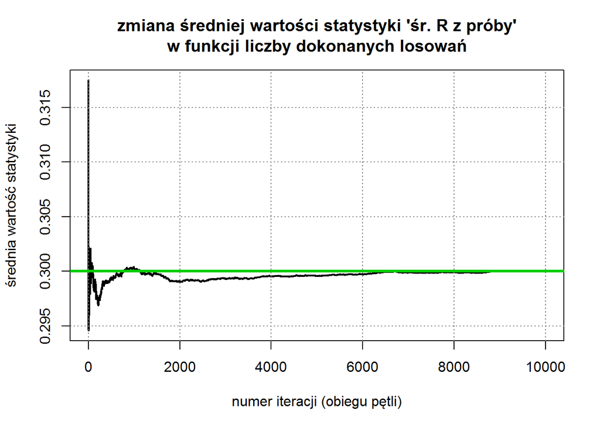

```r
> srSrR = cumsum(srR) / (1:lPowt)
> plot(1:lPowt, srSrR, type = "l", lwd = 2,
+      main = "zmiana średniej wartości statystyki 'śr. R z próby'\nw funkcji liczby dokonanych losowań",
+      xlab = "numer iteracji (obiegu pętli)", ylab = "średnia wartość statystyki")
> grid(col = grey(0.5))
> abline(h = mean(r), col = 3, lwd = 3)
```

Uzyskane wyniki symulacji są więc zgodne z tymi, które wyprowadzone zostały w sposób analityczny.

# Praca domowa

Zostanie nadesłana pocztą.